# Assignment 3: Building and Evaluating Classification Models

Shyni David

2/7/2019

#### Whenever a bank receives an loan application, based on the applicant’s/application profile the bank has to make a decision regarding whether to approve or deny the loan to minimize risk. For this assignment, we will use the German credit data set from the UC Irvine machine learning repository.

#### The data set contains observations on 20 variables (both numerical and categorical) for 1000 past applicants for credit (300 customers rated as bad credit risk and 700 customers rated as good credit risk). More information on the 20 covariates are found that the UCI archive data set description.

#### Attribute Information:

Attribute 1: (qualitative) Status of existing checking account A11 : … < 0 DM A12 : 0 <= … < 200 DM A13 : … >= 200 DM / salary assignments for at least 1 year A14 : no checking account

Attribute 2: (numerical) Duration in month

Attribute 3: (qualitative) Credit history A30 : no credits taken/ all credits paid back duly A31 : all credits at this bank paid back duly A32 : existing credits paid back duly till now A33 : delay in paying off in the past A34 : critical account/ other credits existing (not at this bank)

Attribute 4: (qualitative) Purpose A40 : car (new) A41 : car (used) A42 : furniture/equipment A43 : radio/television A44 : domestic appliances A45 : repairs A46 : education A47 : (vacation - does not exist?) A48 : retraining A49 : business A410 : others

Attribute 5: (numerical) Credit amount

Attibute 6: (qualitative) Savings account/bonds A61 : … < 100 DM A62 : 100 <= … < 500 DM A63 : 500 <= … < 1000 DM A64 : .. >= 1000 DM A65 : unknown/ no savings account

Attribute 7: (qualitative) Present employment since A71 : unemployed A72 : … < 1 year A73 : 1 <= … < 4 years A74 : 4 <= … < 7 years A75 : .. >= 7 years

Attribute 8: (numerical) Installment rate in percentage of disposable income

Attribute 9: (qualitative) Personal status and sex A91 : male : divorced/separated A92 : female : divorced/separated/married A93 : male : single A94 : male : married/widowed A95 : female : single

Attribute 10: (qualitative) Other debtors / guarantors A101 : none A102 : co-applicant A103 : guarantor

Attribute 11: (numerical) Present residence since

Attribute 12: (qualitative) Property A121 : real estate A122 : if not A121 : building society savings agreement/ life insurance A123 : if not A121/A122 : car or other, not in attribute 6 A124 : unknown / no property

Attribute 13: (numerical) Age in years

Attribute 14: (qualitative) Other installment plans A141 : bank A142 : stores A143 : none

Attribute 15: (qualitative) Housing A151 : rent A152 : own A153 : for free

Attribute 16: (numerical) Number of existing credits at this bank

Attribute 17: (qualitative) Job A171 : unemployed/ unskilled - non-resident A172 : unskilled - resident A173 : skilled employee / official A174 : management/ self-employed/ highly qualified employee/ officer

Attribute 18: (numerical) Number of people being liable to provide maintenance for

Attribute 19: (qualitative) Telephone A191 : none A192 : yes, registered under the customers name

Attribute 20: (qualitative) foreign worker A201 : yes A202 : no

Set up library

```r
library(caret)
library(glmnet)
library(caTools)  ##for ROC
library(tidyverse)
```

#### Load the data

```r
 germancredit = read.table("http://archive.ics.uci.edu/ml/machine-learning-databases/statlog/german/german.data")

colnames(germancredit) <- c("chkactstatus", "duration", "credithistory", "purpose", "amount", "saving", "presentjob", "installmentrate", "sexstatus", "otherdebtor", "resident", "property", "age", "otherinstall", "housing", "ncredits", "job", "npeople", "telephone", "foreign", "response")

germancredit$response = as.factor(germancredit$response) # coded as 1=good_risk, 2=bad_risk

table(germancredit$response)
```

```
##
##   1   2
## 700 300
```

```r
str(germancredit)
```

```
## 'data.frame':    1000 obs. of  21 variables:
##  $ chkactstatus   : Factor w/ 4 levels "A11","A12","A13",..: 1 2 4 1 1 4 4 2 4 2 ...
##  $ duration       : int  6 48 12 42 24 36 24 36 12 30 ...
##  $ credithistory  : Factor w/ 5 levels "A30","A31","A32",..: 5 3 5 3 4 3 3 3 3 5 ...
##  $ purpose        : Factor w/ 10 levels "A40","A41","A410",..: 5 5 8 4 1 8 4 2 5 1 ...
##  $ amount         : int  1169 5951 2096 7882 4870 9055 2835 6948 3059 5234 ...
##  $ saving         : Factor w/ 5 levels "A61","A62","A63",..: 5 1 1 1 1 5 3 1 4 1 ...
##  $ presentjob     : Factor w/ 5 levels "A71","A72","A73",..: 5 3 4 4 3 3 5 3 4 1 ...
##  $ installmentrate: int  4 2 2 2 3 2 3 2 2 4 ...
##  $ sexstatus      : Factor w/ 4 levels "A91","A92","A93",..: 3 2 3 3 3 3 3 3 1 4 ...
##  $ otherdebtor    : Factor w/ 3 levels "A101","A102",..: 1 1 1 3 1 1 1 1 1 1 ...
##  $ resident       : int  4 2 3 4 4 4 4 2 4 2 ...
##  $ property       : Factor w/ 4 levels "A121","A122",..: 1 1 1 2 4 4 2 3 1 3 ...
##  $ age            : int  67 22 49 45 53 35 53 35 61 28 ...
##  $ otherinstall   : Factor w/ 3 levels "A141","A142",..: 3 3 3 3 3 3 3 3 3 3 ...
##  $ housing        : Factor w/ 3 levels "A151","A152",..: 2 2 2 3 3 3 2 1 2 2 ...
##  $ ncredits       : int  2 1 1 1 2 1 1 1 1 2 ...
##  $ job            : Factor w/ 4 levels "A171","A172",..: 3 3 2 3 3 2 3 4 2 4 ...
##  $ npeople        : int  1 1 2 2 2 2 1 1 1 1 ...
##  $ telephone      : Factor w/ 2 levels "A191","A192": 2 1 1 1 1 2 1 2 1 1 ...
##  $ foreign        : Factor w/ 2 levels "A201","A202": 1 1 1 1 1 1 1 1 1 1 ...
##  $ response       : Factor w/ 2 levels "1","2": 1 2 1 1 2 1 1 1 1 2 ...
```

Prep it

```r
#The values for the class/response variable must be factors and must be valid names
#recode response variable
germancredit$response <- as.factor(ifelse(germancredit$response == 1, "Good", "Bad"))
levels(germancredit$response)
```

```
## [1] "Bad"  "Good"
```

```r
#Caret's default "Positive" class is the first level of the outcome variable in binary classification
germancredit$response <- relevel(germancredit$response, "Good")
levels(germancredit$response)
```

```
## [1] "Good" "Bad"
```

```r
table(germancredit$response)
```

```
##
## Good  Bad
##  700  300
```

#### Divide into train and test data

```r
set.seed(1234)

in.train <- createDataPartition(germancredit$response, p=0.75, list=FALSE)

#Training data
germancredit.train <- germancredit[in.train,]
dim(germancredit.train)
```

```
## [1] 750  21
```

```r
table(germancredit.train$response)
```

```
##
## Good  Bad
##  525  225
```

```r
#Test Data
germancredit.test <- germancredit[-in.train,]
dim(germancredit.test)
```

```
## [1] 250  21
```

```r
table(germancredit.test$response)
```

```
##
## Good  Bad
##  175   75
```

### 1) a Logistic regression model

```r
modelLookup("glm")
```

```
##   model parameter     label forReg forClass probModel
## 1   glm parameter parameter   TRUE     TRUE      TRUE
```

```r
#for glm there is no parameter tuning performed
cmetric<- "ROC"
logist <- train(response ~., data = germancredit.train, method = "glm", family = "binomial" , metric=cmetric,
               trControl = trainControl("cv", number = 10, summaryFunction=twoClassSummary, classProbs = TRUE)
)

logist
```

```
## Generalized Linear Model
##
## 750 samples
##  20 predictor
##   2 classes: 'Good', 'Bad'
##
## No pre-processing
## Resampling: Cross-Validated (10 fold)
## Summary of sample sizes: 676, 674, 675, 675, 675, 675, ...
## Resampling results:
##
##   ROC        Sens       Spec
##   0.7877915  0.8780479  0.4620553
```

```r
#Model Coefficient on train data
coef(logist$finalModel)
```

```
##      (Intercept)  chkactstatusA12  chkactstatusA13  chkactstatusA14
##     1.054680e+00    -3.886246e-01    -8.574756e-01    -1.645308e+00
##         duration credithistoryA31 credithistoryA32 credithistoryA33
##     3.155039e-02     3.070236e-01    -8.200623e-01    -7.557202e-01
## credithistoryA34       purposeA41      purposeA410       purposeA42
##    -1.533289e+00    -2.185428e+00    -2.823583e+00    -9.488499e-01
##       purposeA43       purposeA44       purposeA45       purposeA46
##    -1.023724e+00    -3.680502e-01    -5.084787e-01    -2.277341e-01
##       purposeA48       purposeA49           amount        savingA62
##    -1.598959e+01    -9.598689e-01     1.592559e-04    -2.676895e-01
##        savingA63        savingA64        savingA65    presentjobA72
##    -4.739896e-01    -1.151423e+00    -1.056732e+00    -2.953746e-01
##    presentjobA73    presentjobA74    presentjobA75  installmentrate
##    -3.303830e-01    -9.678932e-01    -2.999866e-01     3.341439e-01
##     sexstatusA92     sexstatusA93     sexstatusA94  otherdebtorA102
##    -3.624115e-01    -1.068186e+00    -6.494568e-01     4.534580e-01
##  otherdebtorA103         resident     propertyA122     propertyA123
##    -8.426313e-01    -1.248583e-01     1.408802e-01     1.113858e-01
##     propertyA124              age otherinstallA142 otherinstallA143
##     4.007421e-01    -1.078656e-02    -4.234806e-01    -6.425586e-01
##      housingA152      housingA153         ncredits          jobA172
##    -6.062248e-01    -8.503009e-01     2.898696e-01     5.532572e-01
##          jobA173          jobA174          npeople    telephoneA192
##     6.393690e-01     5.805063e-01     3.555227e-01    -2.448168e-01
##      foreignA202
##    -1.380854e+00
```

```r
#install.packages("e1071")
library(e1071)

# Make predictions and calculate confusionmatrix on Test data
probsTest <- predict(logist, type="prob", newdata=germancredit.test)
head(probsTest)
```

```
##         Good       Bad
## 4  0.7390059 0.2609941
## 6  0.8186587 0.1813413
## 7  0.9470916 0.0529084
## 12 0.1365012 0.8634988
## 13 0.7970307 0.2029693
## 22 0.7745149 0.2254851
```

```r
##For a bank specificity is crucial, which means predicting a Bad risk as a Good risk is costly.
##Confusion matrix on train data
confusionMatrix(logist)
```

```
## Cross-Validated (10 fold) Confusion Matrix
##
## (entries are percentual average cell counts across resamples)
##
##           Reference
## Prediction Good  Bad
##       Good 61.5 16.1
##       Bad   8.5 13.9
##
##  Accuracy (average) : 0.7533
```

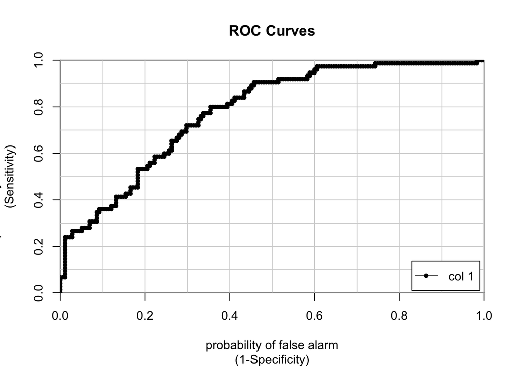

```
##                   [,1]
## Good vs. Bad 0.7798857
```

```r
predslogist <- probsTest[,2]  ##save for later

#Plot the ROC curve Calculate the AUC
colAUC(probsTest[,2], germancredit.test$response, plotROC=TRUE)
```

#### 2) a regularized Linear model using an Elasticnet penalty for shrinkage

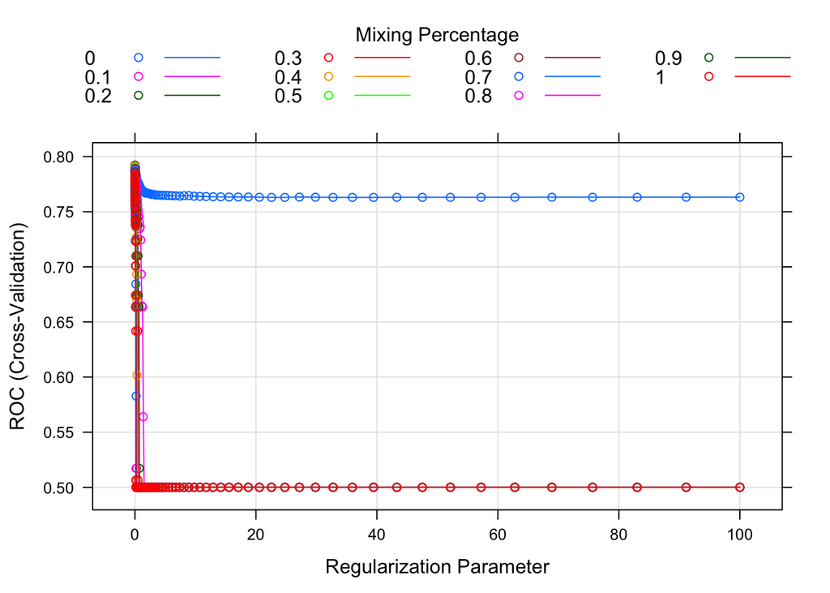

```r
#tunegrid
lambda <- 10^seq(-2, 2, length = 100)
tuneGrid = expand.grid(alpha = seq(0,1,by=0.1), lambda = lambda)

elastic <- train(response ~., data = germancredit.train, method = "glmnet", family="binomial", metric=cmetric, tuneLength = 10, tuneGrid = tuneGrid,
              trControl = trainControl("cv", number = 10, summaryFunction=twoClassSummary, classProbs = TRUE)
)

 plot(elastic)
```

```r
# Model coefficients
coef(elastic$finalModel, elastic$bestTune$lambda)
```

```
## 49 x 1 sparse Matrix of class "dgCMatrix"
##                              1
## (Intercept)       0.1560963689
## chkactstatusA12  -0.2794184110
## chkactstatusA13  -0.7547750074
## chkactstatusA14  -1.4384175760
## duration          0.0291460419
## credithistoryA31  0.7284921780
## credithistoryA32 -0.2159192425
## credithistoryA33 -0.1575054331
## credithistoryA34 -0.8467597088
## purposeA41       -1.6546811233
## purposeA410      -2.0076552052
## purposeA42       -0.5771584819
## purposeA43       -0.7734723579
## purposeA44       -0.1570307822
## purposeA45       -0.1677831362
## purposeA46       -0.0106700022
## purposeA48       -3.1689023079
## purposeA49       -0.5517256983
## amount            0.0001264082
## savingA62        -0.1765745488
## savingA63        -0.4387027309
## savingA64        -0.9625288200
## savingA65        -0.8669605927
## presentjobA72     0.0487840945
## presentjobA73     .
## presentjobA74    -0.4995430042
## presentjobA75    -0.0087212175
## installmentrate   0.2533537171
## sexstatusA92      .
## sexstatusA93     -0.6167423301
## sexstatusA94     -0.2841685029
## otherdebtorA102   0.3843850961
## otherdebtorA103  -0.6637443753
## resident         -0.0856925221
## propertyA122      0.0808327080
## propertyA123      0.0780336339
## propertyA124      0.1979279992
## age              -0.0085592371
## otherinstallA142 -0.2398496762
## otherinstallA143 -0.5258000775
## housingA152      -0.4544440018
## housingA153      -0.4477455795
## ncredits          0.2198339357
## jobA172          -0.0238365189
## jobA173           0.0913991400
## jobA174           0.1126568093
## npeople           0.2267315250
## telephoneA192    -0.2137142840
## foreignA202      -1.0130101500
```

```r
# Make predictions and calculate confusionmatrix on Test data
probsTest <- predict(elastic, type="prob", newdata=germancredit.test)
head(probsTest)
```

```
##        Good        Bad
## 1 0.6331544 0.36684561
## 2 0.7814672 0.21853276
## 3 0.9226913 0.07730869
## 4 0.1563450 0.84365500
## 5 0.7619648 0.23803522
## 6 0.7802874 0.21971258
```

```r
##Confusion matrix on train data
confusionMatrix(elastic)
```

```
## Cross-Validated (10 fold) Confusion Matrix
##
## (entries are percentual average cell counts across resamples)
##
##           Reference
## Prediction Good  Bad
##       Good 62.4 16.0
##       Bad   7.6 14.0
##
##  Accuracy (average) : 0.764
```

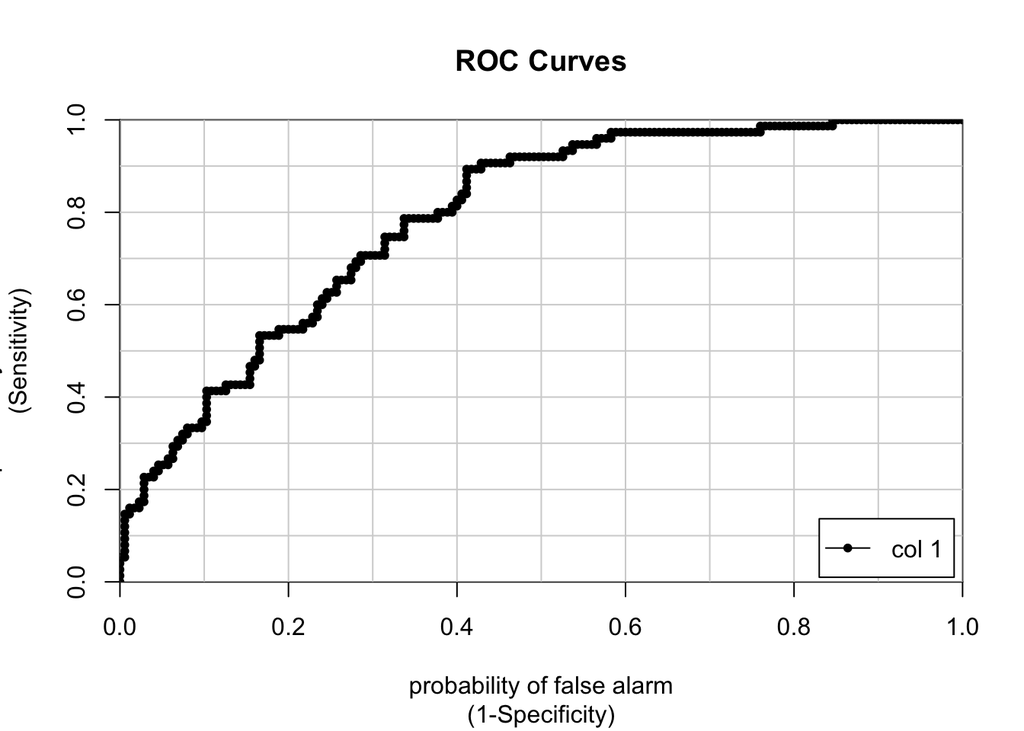

```r
predselastic <-probsTest[,2]  #save for later

#Plot the ROC curveCalculate the AUROC
f <- colAUC(probsTest[,2], germancredit.test$response, plotROC=TRUE)
```

#### (3) a tree model (method=“rpart”)

```r
#number of variables sampled as candidate at each split is default sqrt(p) where p is number of variables in train data

#Method 'rpart' is only capable of tuning cp
tuneGridtree <- expand.grid( cp=seq(0,0.1, 0.01))


tree <- train(response ~., data = germancredit.train, method = "rpart", metric=cmetric, tuneGrid = tuneGridtree,
              trControl = trainControl("cv", number = 10, summaryFunction=twoClassSummary, classProbs = TRUE)
)

tree
```

```
## CART
##
## 750 samples
##  20 predictor
##   2 classes: 'Good', 'Bad'
##
## No pre-processing
## Resampling: Cross-Validated (10 fold)
## Summary of sample sizes: 676, 674, 676, 675, 674, 676, ...
## Resampling results across tuning parameters:
##
##   cp    ROC        Sens       Spec
##   0.00  0.6992469  0.8038824  0.41679842
##   0.01  0.7304380  0.8554427  0.42193676
##   0.02  0.7164809  0.8993106  0.35968379
##   0.03  0.7104878  0.8936139  0.34624506
##   0.04  0.6678606  0.9165457  0.25316206
##   0.05  0.5722073  0.9753991  0.06225296
##   0.06  0.5000000  1.0000000  0.00000000
##   0.07  0.5000000  1.0000000  0.00000000
##   0.08  0.5000000  1.0000000  0.00000000
##   0.09  0.5000000  1.0000000  0.00000000
##   0.10  0.5000000  1.0000000  0.00000000
##
## ROC was used to select the optimal model using the largest value.
## The final value used for the model was cp = 0.01.
```

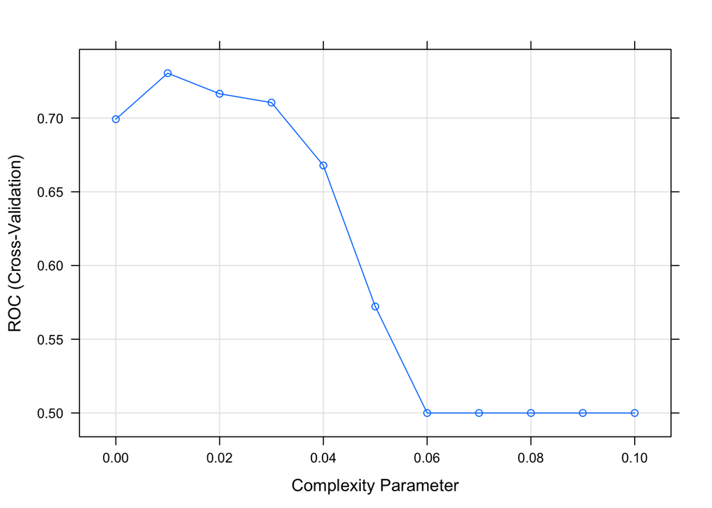

```r
plot(tree)
```

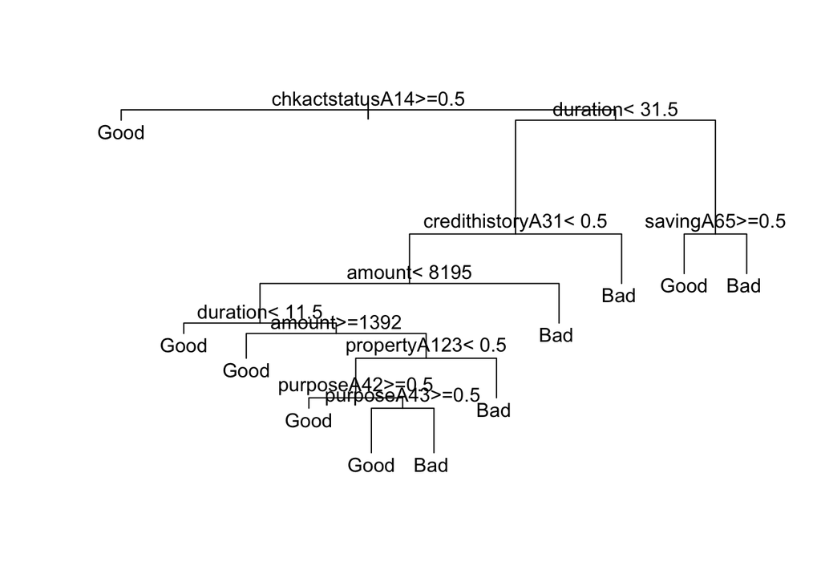

```r
#Visualize the tree
par(xpd = NA) # Avoid clipping the text in some device
plot(tree$finalModel)
text(tree$finalModel, digits = 3)
```

```r
# Make predictions and calculate confusionmatrix on Test data
probsTest <- predict(tree, type="prob", newdata=germancredit.test)
head(probsTest)
```

```
##         Good       Bad
## 4  0.2876712 0.7123288
## 6  0.8724832 0.1275168
## 7  0.8724832 0.1275168
## 12 0.2876712 0.7123288
## 13 0.6914894 0.3085106
## 22 0.8714286 0.1285714
```

```r
##Confusion matrix on train data
confusionMatrix(tree)
```

```
## Cross-Validated (10 fold) Confusion Matrix
##
## (entries are percentual average cell counts across resamples)
##
##           Reference
## Prediction Good  Bad
##       Good 59.9 17.3
##       Bad  10.1 12.7
##
##  Accuracy (average) : 0.7253
```

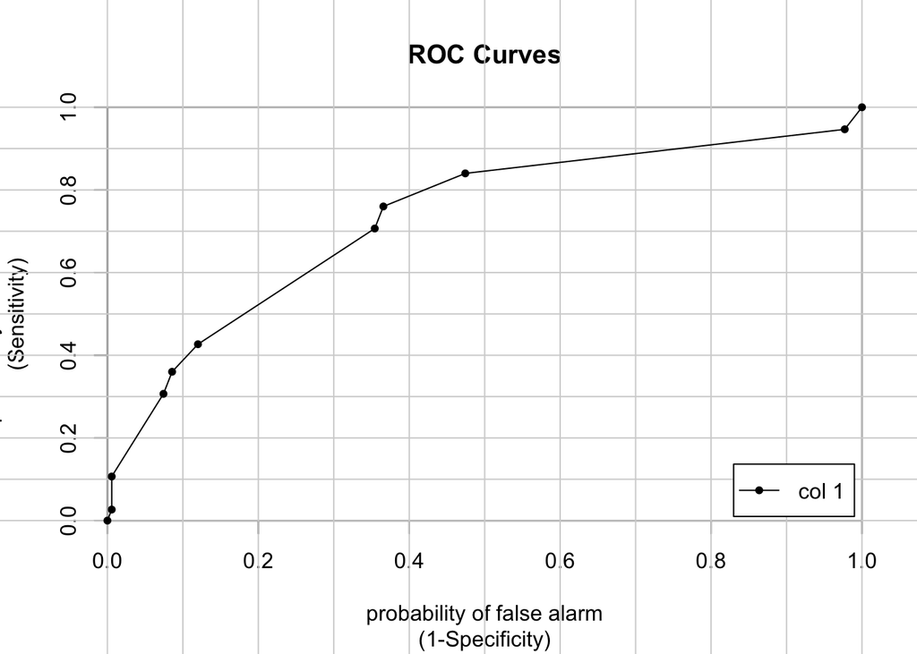

```
##                   [,1]
## Good vs. Bad 0.7310095
```

```r
predstree <- probsTest[,2]  ##save for later

#Plot the ROC curveCalculate the AUROC
colAUC(probsTest[,2], germancredit.test$response, plotROC=TRUE)
```

```r
##tuning
```

#### (4) a Neural Network

```r
#
nnetGrid <- expand.grid(size = seq(from = 1, to = 10, by = 1),#number of units in hidden layer
    decay = seq(from = 0.1, to = 0.5, by = 0.1)) #weight to avoid over fitting

NN <- train(response ~., data = germancredit.train, method = "nnet", preProcess = "range", metric=cmetric, tunelength =5, maxit=1000, linout=FALSE,  tuneGrid = nnetGrid,
                trControl = trainControl("cv", number = 10, summaryFunction=twoClassSummary, classProbs = TRUE)
)
NN
```

```
## Neural Network
##
## 750 samples
##  20 predictor
##   2 classes: 'Good', 'Bad'
##
## Pre-processing: re-scaling to [0, 1] (48)
## Resampling: Cross-Validated (10 fold)
## Summary of sample sizes: 674, 675, 675, 675, 675, 675, ...
## Resampling results across tuning parameters:
##
##   size  decay  ROC        Sens       Spec
##    1    0.1    0.7772085  0.8552612  0.5156126
##    1    0.2    0.7809727  0.8723875  0.5112648
##    1    0.3    0.7814701  0.8837083  0.5021739
```

[output cut: 50 more lines]

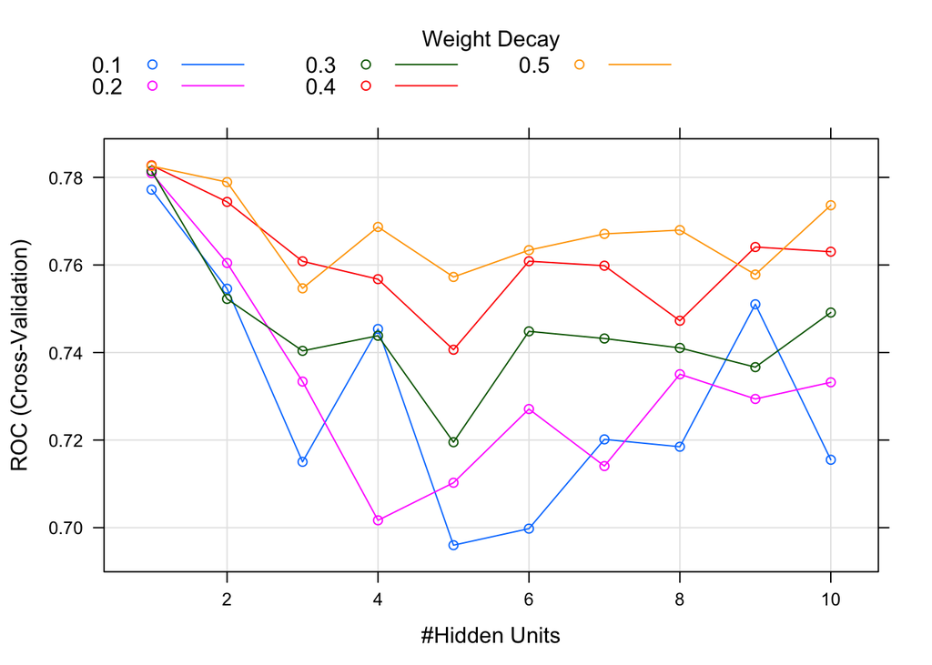

```r
plot(NN)
```

```r
# Model coefficients
coef(NN$finalModel, NN$bestTune$lambda)
```

```
##         b->h1        i1->h1        i2->h1        i3->h1        i4->h1
## -1.4565018589  0.2757362360  0.7389306448  1.2951347027 -1.8039725473
##        i5->h1        i6->h1        i7->h1        i8->h1        i9->h1
## -0.4875459475  0.5249997635  0.4891802766  1.0232815008  1.4543518802
##       i10->h1       i11->h1       i12->h1       i13->h1       i14->h1
##  1.0522547251  0.5682398201  0.7355512907 -0.0411118556  0.3719235425
##       i15->h1       i16->h1       i17->h1       i18->h1       i19->h1
## -0.0424652549  1.1559634892  0.4893944432 -1.9408294818  0.2216563867
##       i20->h1       i21->h1       i22->h1       i23->h1       i24->h1
##  0.1606951722  0.9844925847  0.7498537200 -0.0390593448  0.1569998485
##       i25->h1       i26->h1       i27->h1       i28->h1       i29->h1
##  0.5089832979  0.1706833262 -0.6601394880  0.0717418355  0.6317152164
##       i30->h1       i31->h1       i32->h1       i33->h1       i34->h1
##  0.3377410696 -0.5306944912  0.5400598111  0.2671212970 -0.0004546986
##       i35->h1       i36->h1       i37->h1       i38->h1       i39->h1
## -0.0856542995 -0.3053072759  0.3127364123  0.1486584454  0.3563533423
##       i40->h1       i41->h1       i42->h1       i43->h1       i44->h1
##  0.3492751530  0.6096801039 -0.4743445138 -0.2540706697 -0.4159651207
##       i45->h1       i46->h1       i47->h1       i48->h1          b->o
## -0.4516321958 -0.1829568711  0.2164451918  0.8984637234  1.8219394589
##         h1->o
## -5.2365745818
```

```r
# Make predictions and calculate confusionmatrix on Test data
probsTest <- predict(NN, type="prob", newdata=germancredit.test)
head(probsTest)
```

```
##         Good        Bad
## 4  0.7039330 0.29606702
## 6  0.8341179 0.16588206
## 7  0.9148332 0.08516677
## 12 0.2130426 0.78695744
## 13 0.7865312 0.21346877
## 22 0.7659415 0.23405855
```

```r
##Confusion matrix on train data
confusionMatrix(NN)
```

```
## Cross-Validated (10 fold) Confusion Matrix
##
## (entries are percentual average cell counts across resamples)
##
##           Reference
## Prediction Good  Bad
##       Good 62.0 15.5
##       Bad   8.0 14.5
##
##  Accuracy (average) : 0.7653
```

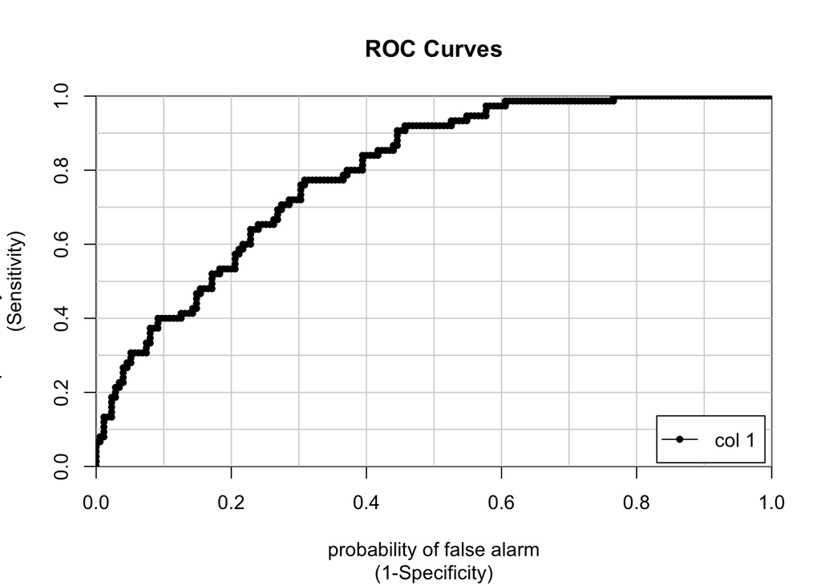

```
##                [,1]
## Good vs. Bad 0.7952
```

```r
predsNN <-probsTest[,2]  #save for later

#Plot the ROC curveCalculate the AUROC
colAUC(probsTest[,2], germancredit.test$response, plotROC=TRUE)
```

#### Compare the performance of four candidate classification models

```r
models <- list(logistic=logist, elastic = elastic, tree=tree, NN=NN)
results <- resamples(models)
summary(results)
```

```
##
## Call:
## summary.resamples(object = results)
##
## Models: logistic, elastic, tree, NN
## Number of resamples: 10
##
## ROC
##               Min.   1st Qu.    Median      Mean   3rd Qu.      Max. NA's
## logistic 0.7399666 0.7648221 0.7952495 0.7877915 0.8057164 0.8301887    0
## elastic  0.7316054 0.7442931 0.7613314 0.7922004 0.8377769 0.9064685    0
## tree     0.6865352 0.7031915 0.7148279 0.7304380 0.7517432 0.7980769    0
## NN       0.6981605 0.7405660 0.7955686 0.7827517 0.8236905 0.8589007    0
##
## Sens
##               Min.   1st Qu.    Median      Mean   3rd Qu.      Max. NA's
## logistic 0.7924528 0.8515965 0.8942308 0.8780479 0.9056604 0.9433962    0
## elastic  0.8113208 0.8701923 0.9056604 0.8916183 0.9187228 0.9615385    0
## tree     0.7735849 0.8277395 0.8490566 0.8554427 0.8948657 0.9230769    0
## NN       0.8461538 0.8660196 0.8773585 0.8857039 0.9052068 0.9615385    0
##
## Spec
##               Min.   1st Qu.    Median      Mean   3rd Qu.      Max. NA's
## logistic 0.3181818 0.4204545 0.4664032 0.4620553 0.4782609 0.6363636    0
## elastic  0.3478261 0.4021739 0.4446640 0.4673913 0.5000000 0.6818182    0
## tree     0.2173913 0.3364625 0.4090909 0.4219368 0.5108696 0.5909091    0
## NN       0.3043478 0.4510870 0.5000000 0.4845850 0.5395257 0.5652174    0
```

```r
summary(results, metric="ROC")
```

```
##
## Call:
## summary.resamples(object = results, metric = "ROC")
##
## Models: logistic, elastic, tree, NN
## Number of resamples: 10
##
## ROC
##               Min.   1st Qu.    Median      Mean   3rd Qu.      Max. NA's
## logistic 0.7399666 0.7648221 0.7952495 0.7877915 0.8057164 0.8301887    0
## elastic  0.7316054 0.7442931 0.7613314 0.7922004 0.8377769 0.9064685    0
## tree     0.6865352 0.7031915 0.7148279 0.7304380 0.7517432 0.7980769    0
## NN       0.6981605 0.7405660 0.7955686 0.7827517 0.8236905 0.8589007    0
```

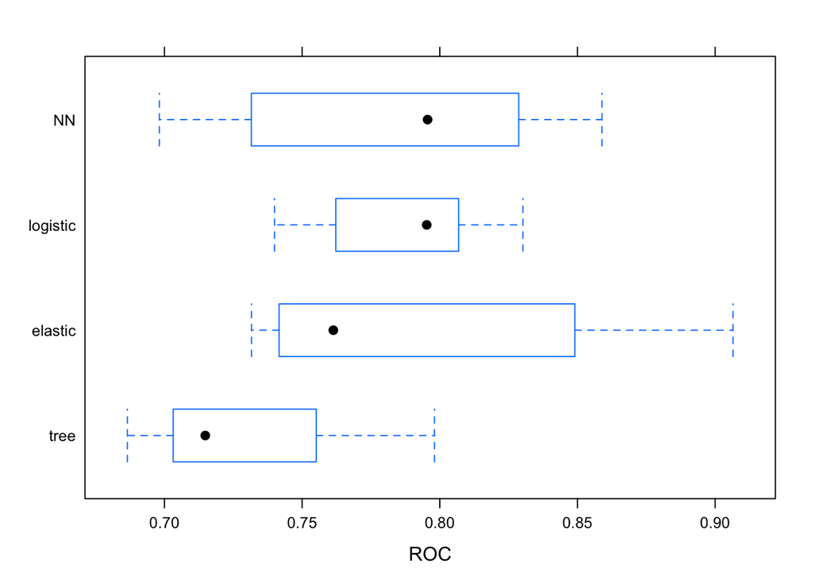

```r
bwplot(results, metric="ROC")
```

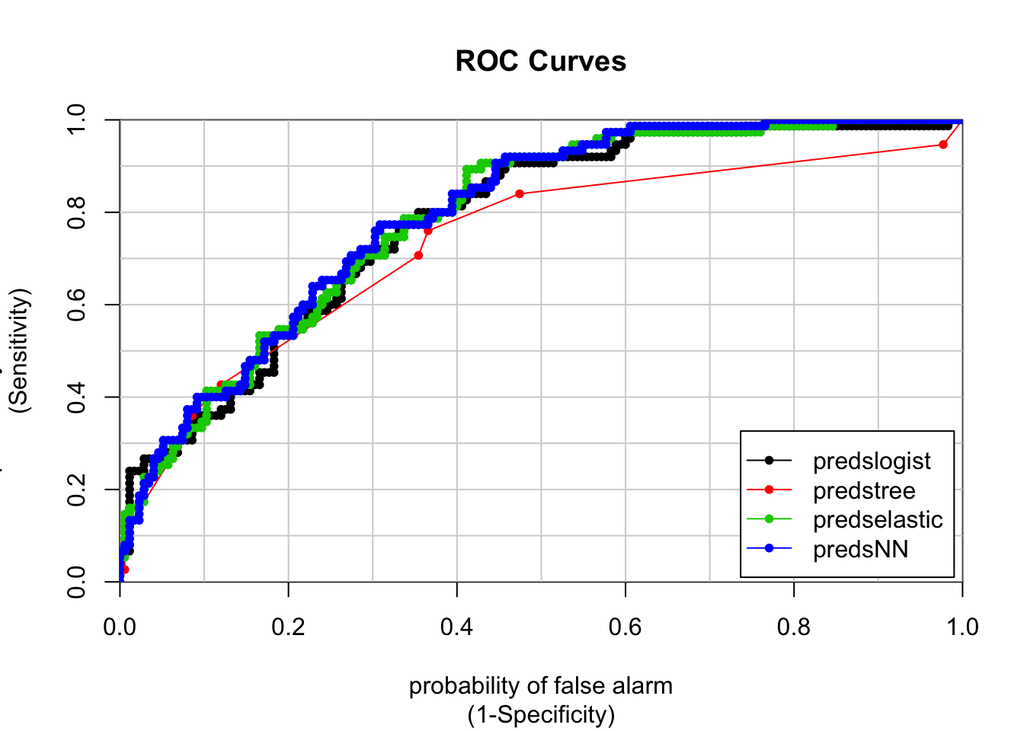

```
##              predslogist predstree predselastic predsNN
## Good vs. Bad   0.7798857 0.7310095    0.7892571  0.7952
```

```r
colAUC(cbind(predslogist,predstree, predselastic, predsNN), germancredit.test$response, plotROC=TRUE)
```

#### The ElasticNet model built with training data is the best fit model with the highest AUC of 0.7922.

#### When the model is tested with test data the best fit is the Neural Network model with the maximum AUC of 0.7952.